# [`ConformalPrediction.jl`](https://github.com/JuliaTrustworthyAI/ConformalPrediction.jl)

Predictive Uncertainty Quantification in Machine Learning

Patrick Altmeyer

Delft University of Technology

Delft University of Technology

[Patrick Altmeyer](https://www.patalt.org/)

November 4, 2026

## Talk Agenda<sup>1</sup>

1. Introduction (5min)
2. Applications (5min)
3. Interactive demo of [`ConformalPrediction.jl`](https://github.com/JuliaTrustworthyAI/ConformalPrediction.jl) (10min)
4. Under Construction (5min)
5. Q&A

> Code along 💻 tinyurl.com/cpjcon2023

[figure not shown]

Feeling lucky? Use binder!

[^1]: Link to slides: tinyurl.com/cpjcon2023slides

## Conformal Prediction

Conformal Prediction involves turning heuristic measures of Predictive Uncertainty into rigorous ones.

> A first crucial step towards building trustworthy AI systems is to be transparent about predictive uncertainty.

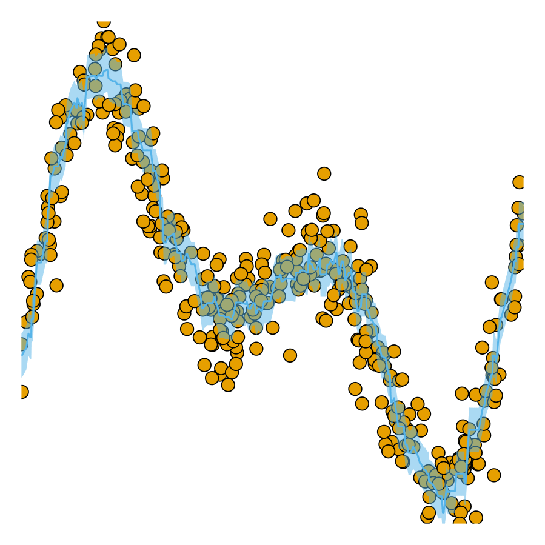

## Example: Split CP

1. Proper training set and separate calibration set: $\mathcal{D}_n=\mathcal{D}^{\text{train}} \cup \mathcal{D}^{\text{cali}}$.
2. Train model on proper training set: $\hat\mu_{i \in \mathcal{D}^{\text{train}}}(X_i,Y_i)$.
3. Compute nonconformity scores, $\mathcal{S}$, using calibration data $\mathcal{D}^{\text{cali}}$ and fitted model $\hat\mu_{i \in \mathcal{D}^{\text{train}}}$.
4. For user-specified coverage ratio $(1-\alpha)$ compute the corresponding quantile, $\hat{q}$, of $\mathcal{S}$.
5. For the given quantile and test sample $X_{\text{test}}$, form the corresponding conformal prediction set: $C(X_{\text{test}})=\{y:s(X_{\text{test}},y) \le \hat{q}\}$.

**Blog posts**

- Conformal Classification ([[blog](https://www.patalt.org/blog/posts/conformal-prediction/)], [[TDS](https://towardsdatascience.com/conformal-prediction-in-julia-351b81309e30)], [[Forem](https://forem.julialang.org/patalt/conformal-prediction-in-julia-h9n)])
- Conformal Regression ([[blog](https://www.patalt.org/blog/posts/conformal-regression/)], [[TDS](https://towardsdatascience.com/prediction-intervals-for-any-regression-model-306930d5ad9a)], [[Forem](https://forem.julialang.org/patalt/prediction-intervals-for-any-regression-model-16f5)])

## Split CP illustrated

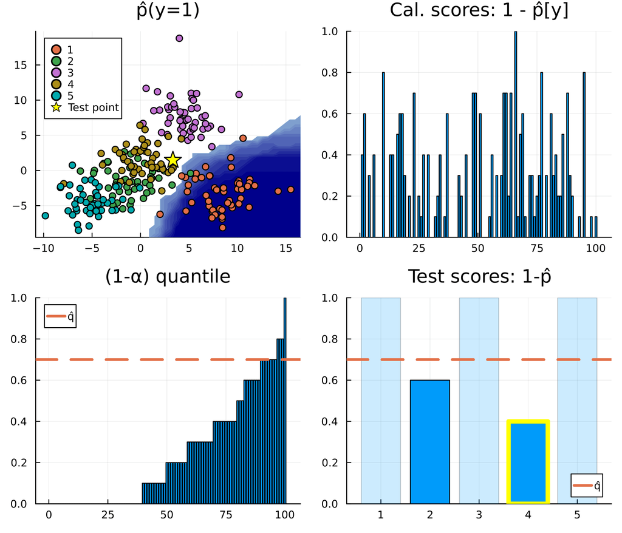

Figure 1: Softmax output for class 1 (top left); non-conformity scores for calibration set (top right); (1-α)-quantile (bottom left); non-conformity function applied to test point (bottom right). Solid bars make it into prediction set.

# [`ConformalPrediction.jl`](https://github.com/JuliaTrustworthyAI/ConformalPrediction.jl)

- Built on top of [`MLJ.jl`](https://alan-turing-institute.github.io/MLJ.jl/dev/).
- Compatible with [`Flux.jl`](https://fluxml.ai/) through [`MLJFlux.jl`](https://github.com/FluxML/MLJFlux.jl).
- Many state-of-the-art CP methods implemented for regression, classification and time series modelling.

[figure not shown]

[figure not shown]

# 🔍 Applications

## CP meets SR

Remember [`SymbolicRegression.jl`](https://github.com/MilesCranmer/SymbolicRegression.jl) by Miles Cranmer?

```julia
# Standard MLJ workflow:
using MLJ
import SymbolicRegression: SRRegressor
model = SRRegressor(
  niterations=50,
  binary_operators=[+, -, *],
  unary_operators=[sin],
)

# Conformalize:
using ConformalPrediction
conf_model = conformal_model(model)
mach = machine(conf_model, X, y)
fit!(mach, rows=train)
```

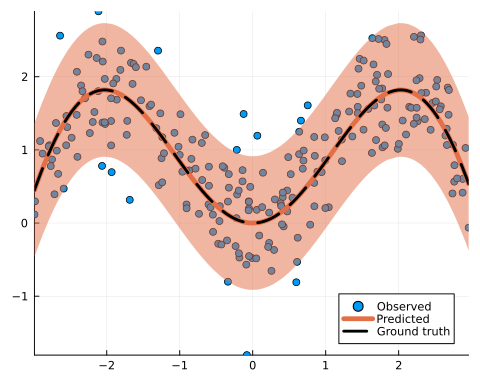

## Conformal Chatbot

- Overview
- Demo

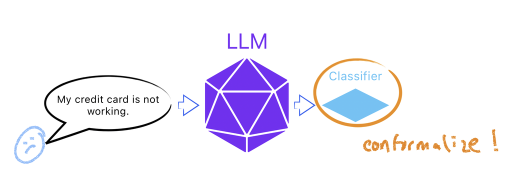

Figure 2: High-level overview of Conformal Intent Classifier. Won 1st 🏆 at ING Global Experiment Week 2023.

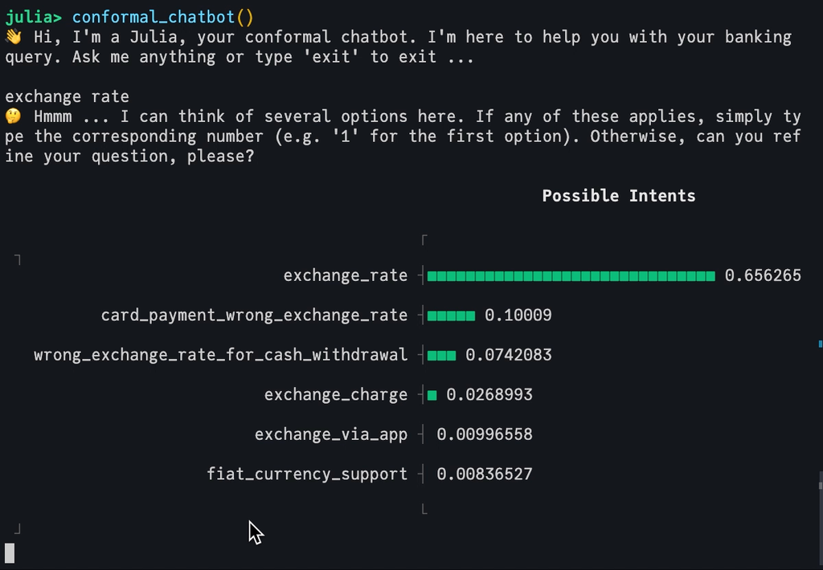

Figure 3: Demo of a REPL-based conformalized intent classifier.

**Blog post**

Building a Conformal Chatbot in Julia ([blog](https://www.patalt.org/blog/posts/conformal-llm/), [TDS](https://medium.com/towards-data-science/building-a-conformal-chatbot-in-julia-1ed23363a280))

## Conformal Image Classifier

A simple MNIST classifier.

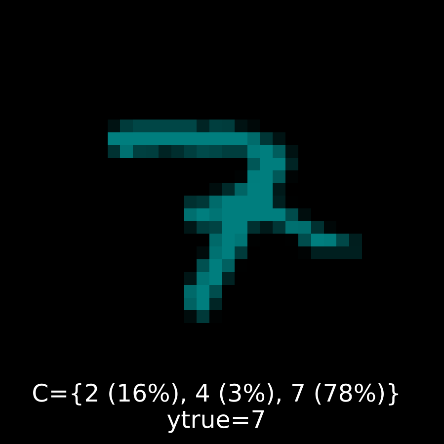

Figure 4: Probably a 7 🤔

```julia
# MLJFlux workflow:
using MLJFlux
ImageClassifier = @load ImageClassifier

# Conformalize:
using ConformalPrediction
conf_model = conformal_model(clf)
mach = machine(conf_model, X, y)
fit!(mach)
```

**Blog post**

How to Conformalize a Deep Image Classifier ([blog](https://www.patalt.org/blog/posts/conformal-image-classifier/), [TDS](https://medium.com/towards-data-science/how-to-conformalize-a-deep-image-classifier-14ead4e1a5a0), [Forem](https://forem.julialang.org/patalt/how-to-conformalize-a-deep-image-classifier-50p2))

## Time Series

Ensemble Batch Prediction Intervals (Xu and Xie 2021) contributed by [Mojtaba Farmanbar](https://www.linkedin.com/in/mfarmanbar/) 📣.

**Tutorial**

How to Conformalize a Time Series Model ([docs](https://juliatrustworthyai.github.io/ConformalPrediction.jl/stable/how_to_guides/timeseries/))

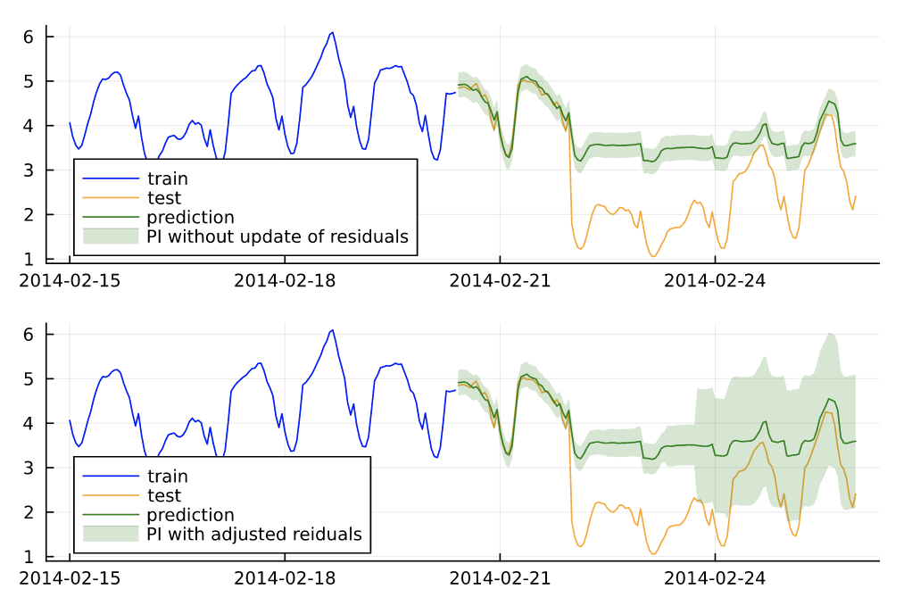

Figure 5: EnbPI for Victoria electricity demand dataset.

# 🏃 Interactive Session

# 🚧 Under Construction

## Conformal [`LaplaceRedux.jl`](https://github.com/juliatrustworthyai/LaplaceRedux.jl)

- Predictive posterior as heuristic (Angelopoulos and Bates 2022).
- Importance Sampling (Fong and Holmes 2021).

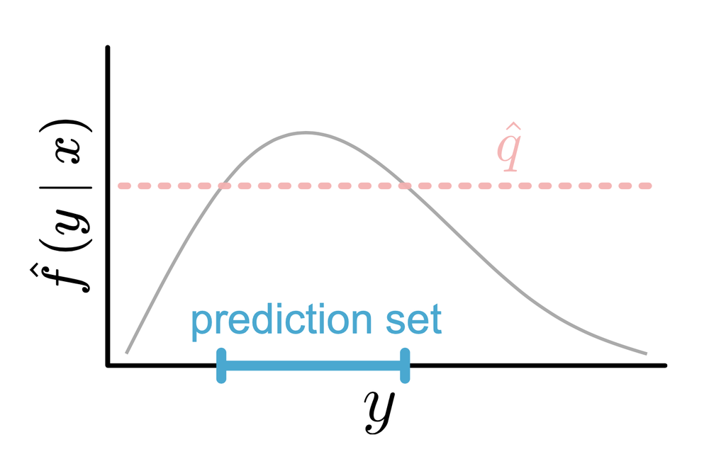

**Contribute**

[`LaplaceRedux.jl`](https://github.com/juliatrustworthyai/LaplaceRedux.jl) interfaced to [`MLJFlux.jl`](https://github.com/FluxML/MLJFlux.jl). Planning to add both ideas [[#64](https://github.com/JuliaTrustworthyAI/ConformalPrediction.jl/issues/64)].

## Conformal Counterfactuals

[figure not shown]

Stutz et al. (2022) introduce Conformal Training: conformal predictions (left), set size (centre) and smooth set size loss (right).

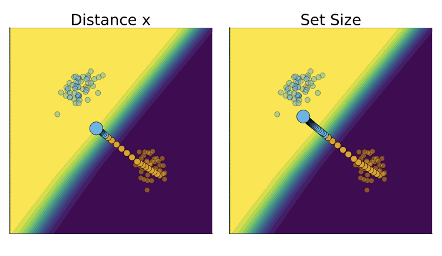

Conformal [`CounterfactualExplanations.jl`](https://github.com/juliatrustworthyai/CounterfactualExplanations.jl).

**Contribute**

Currently working on full conformal training implementation [[#62](https://github.com/JuliaTrustworthyAI/ConformalPrediction.jl/issues/62)].

# 🗨️ and finally …

## Trustworthy AI in `Julia`

Taija collects Julia packages geared towards Trustworthy AI:

- [`CounterfactualExplanations.jl`](https://github.com/juliatrustworthyai/CounterfactualExplanations.jl)
- [`ConformalPrediction.jl`](https://github.com/juliatrustworthyai/ConformalPrediction.jl)
- [`LaplaceRedux.jl`](https://github.com/juliatrustworthyai/LaplaceRedux.jl)
- [`JointEnergyModels.jl`](https://github.com/juliatrustworthyai/JointEnergyModels.jl)
- …

> Contributions welcome! 😊

[figure not shown]

## References

Angelopoulos, Anastasios N., and Stephen Bates. 2022. *A Gentle Introduction to Conformal Prediction and Distribution-Free Uncertainty Quantification*. https://arxiv.org/abs/2107.07511.

Fong, Edwin, and Chris Holmes. 2021. *Conformal Bayesian Computation*. arXiv. https://doi.org/10.48550/arXiv.2106.06137.

Stutz, David, Krishnamurthy, Dvijotham, Ali Taylan Cemgil, and Arnaud Doucet. 2022. *Learning Optimal Conformal Classifiers*. https://arxiv.org/abs/2110.09192.

Xu, Chen, and Yao Xie. 2021. “Conformal Prediction Interval for Dynamic Time-Series.” July, 11559–69. https://proceedings.mlr.press/v139/xu21h.html.